# Project: Ford GoBike System Data

### What is the relation between ages and type of user ?

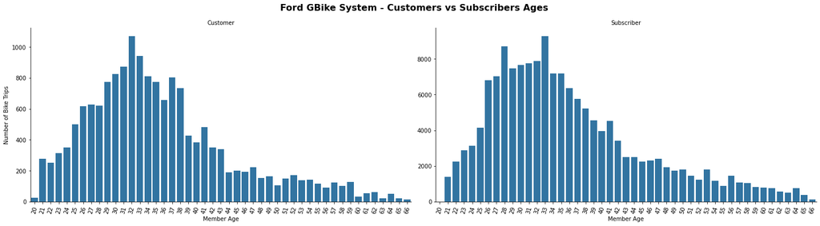

### What is the distriputaion of start hour depending on user type ?

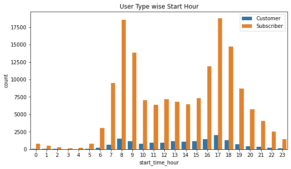

> Observation(5): Subscribers take trips mostly during 8-9 am and 4-6 pm which is usually working hours of a company.

## Multivariate Exploration

> I created plots of three or more variables to investigate the Ford Go Bike data even further.

### what is the relation between trips taken by customers and subscribers on weekdays and weekends ?

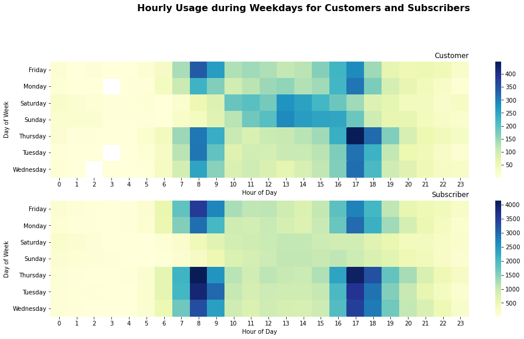

> Observation(2): we can see clearly the trips taken by customers and subscribers on weekdays and weekends.